# Statistics in Python: Uniform Distributions

⇦ Back

If someone ever wants to generate a ‘random number’ it usually means that they want a random number from a *uniform distribution:* they want the chance of getting any one number to be the same as the chance of getting any other number. The chances of particular numbers appearing is *uniform* - hence the name. They will often also want that random number to be an integer, which implies that they want it to come from a *discrete* uniform distribution. If they want that random number to be any decimal, it implies they want it to come from a *continuous* uniform distribution.

You might be aware that, in general, computers can’t actually produce truly random numbers and can only produce *pseudorandom* numbers. For the purposes of this page this fact makes no difference.

# 1 Packages

The code on this page uses the `numpy`, `matplotlib` and `scipy` packages. These can be installed from the terminal with:

```bash
$ python3.11 -m pip install numpy
$ python3.11 -m pip install matplotlib
$ python3.11 -m pip install scipy
```

where `python3.11` corresponds to the version of Python you have installed and are using.

Import these packages into Python with:

```python
import numpy as np
from scipy import stats as st
from matplotlib import pyplot as plt
```

# 2 Continuous Uniform Distributions

A number sampled from a continuous uniform distribution that runs from $A$ to $B$ can have any value between those two endpoints with no value being more or less likely than any other possible value.

In Python, the `uniform()` function from **SciPy** samples from a closed interval by default while the `uniform()` function from **NumPy** samples from a half-open one - $[A, B)$ - by default. SciPy also gives us access to the probability density function (PDF), cumulative distribution function (CDF) and percent point function (PPF) while NumPy simply lets us draw random numbers.

## 2.1 Probability Density Function

The PDF from SciPy:

```python
# We want to display the PDF on the plot from -1.5 to 11.5
x = np.linspace(-1.5, 11.5, 1000)
# Probability density function
# (scaled up so as to run from 0 to 10)
pdf = st.uniform.pdf(x, loc=0, scale=10)
```

Random numbers from NumPy:

```python
# Set the seed so that we get the same random numbers each time this code runs
np.random.seed(20230809)

# Pick 300 random numbers between 0 and 10
n = 300
random_numbers = np.random.uniform(0, 10, n)
```

Here’s what they look like on a plot:

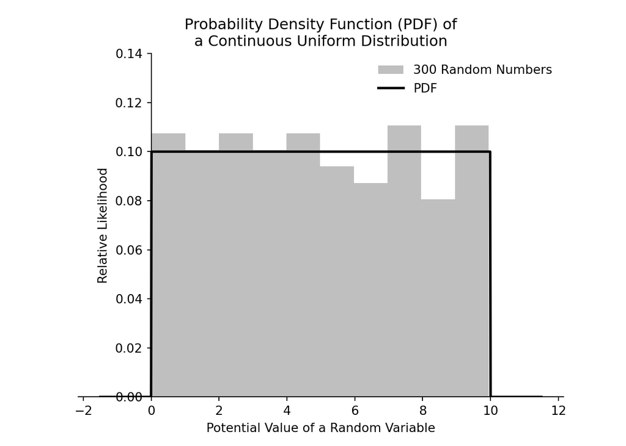

```python
# Create plot
ax = plt.axes()
title = """Probability Density Function (PDF) of
a Continuous Uniform Distribution"""
ax.set_title(title)
ax.set_ylabel('Relative Likelihood')
ax.set_xlabel('Potential Value of a Random Variable')
# Plot the random numbers
label = '300 Random Numbers'
ax.hist(random_numbers, density=True, label=label, color='gray', alpha=0.5)
# Plot the PDF
ax.plot(x, pdf, c='k', lw=2, label='PDF')
# Move the left axis
ax.spines['left'].set_position(('data', 0))
# Remove the upper and right axes
ax.spines['right'].set_color('none')
ax.spines['top'].set_color('none')
# Adjust axes
plt.ylim([0, 0.14])
# Finish
ax.legend(frameon=False)
plt.show()
```

## 2.2 Cumulative Distribution Function

The CDF from SciPy:

```python
# We want to display the CDF on the plot from -1.5 to 11.5
x = np.linspace(-1.5, 11.5, 1000)
# Cumulative distribution function
# (scaled up so as to run from 0 to 10)
cdf = st.uniform.cdf(x, loc=0, scale=10)
```

Area under the plot of the random numbers from NumPy:

```python
# Cumulative sum of random numbers
random_numbers.sort()
auc = [np.trapz([0.1] * i, random_numbers[:i]) for i in range(300)]
```

In a plot:

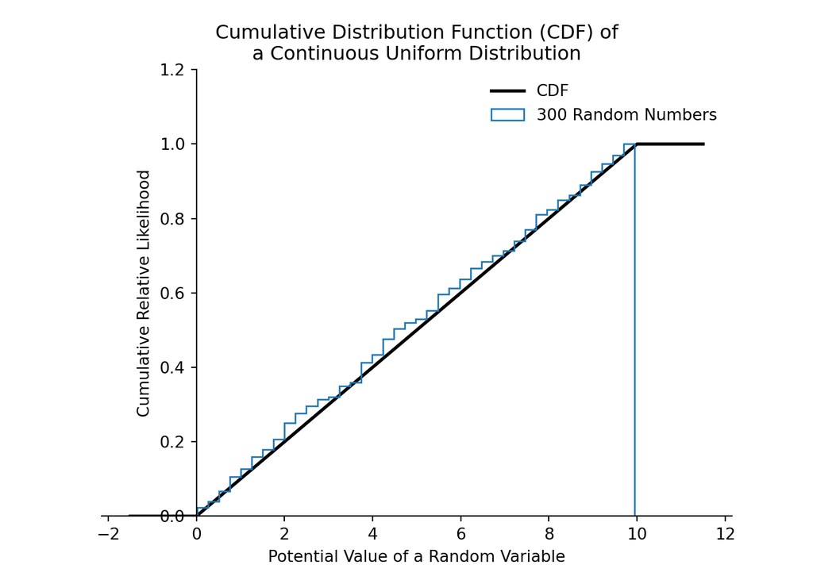

```python
# Create plot
ax = plt.axes()
title = """Cumulative Distribution Function (CDF) of
a Continuous Uniform Distribution"""
ax.set_title(title)
ax.set_ylabel('Cumulative Relative Likelihood')
ax.set_xlabel('Potential Value of a Random Variable')
# Plot the CDF
ax.plot(x, cdf, c='k', lw=2, label='CDF')
# Plot the cumulative sum of the random numbers
label = '300 Random Numbers'
ax.hist(
    random_numbers, bins=40, density=True, cumulative=True,
    histtype='step', label=label
)
# Move the left axis
ax.spines['left'].set_position(('data', 0))
# Remove the upper and right axes
ax.spines['right'].set_color('none')
ax.spines['top'].set_color('none')
# Adjust axes
plt.ylim([0, 1.2])
# Finish
ax.legend(frameon=False)
plt.show()
```

See also the [Wikipedia page](https://en.wikipedia.org/wiki/Continuous_uniform_distribution), [SciPy documentation](https://docs.scipy.org/doc/scipy/reference/generated/scipy.stats.uniform.html) and [NumPy documentation](https://numpy.org/doc/stable/reference/random/generated/numpy.random.uniform.html) relevant to the continuous uniform distribution.

# 3 Discrete Uniform Distributions

This concept is exactly the same as continuous distributions except now there are only a finite number of possibilities that the values of the random numbers can have. The classic example is a die roll: there are only 6 values that a roll can result in and all 6 are equally likely. The fact that the probability of getting a particular exact value is not zero (as is the case with continuous distributions) means that the probability *density* is not relevant, the probability *mass* is. In other words, we work with exact probabilities, not relative likelihoods.

## 3.1 Probability Mass Function

The PMF from SciPy:

```python
# We want to display the PMF on the plot from 0 to 7
x = np.linspace(0, 7, 701)
# Probability mass function
# (running from 1 to 6)
pmf = st.randint.pmf(x, low=1, high=7)
```

Random numbers from NumPy:

```python
# Pick 300 random integers between 1 and 6
n = 300
random_numbers = np.random.randint(1, 7, n)
```

Here’s what they look like on a plot:

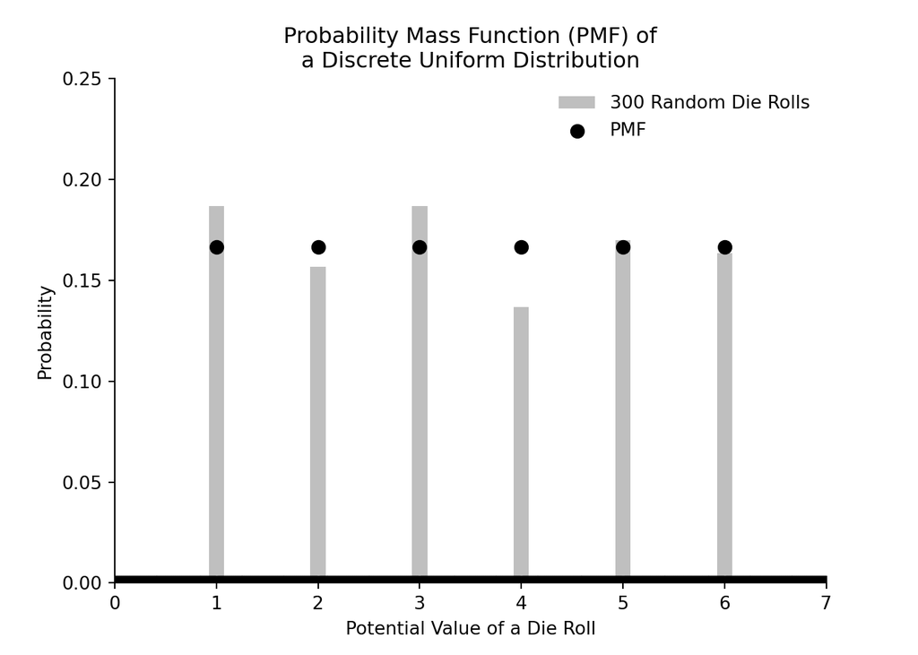

```python
# Create plot
ax = plt.axes()
title = """Probability Mass Function (PMF) of
a Discrete Uniform Distribution"""
ax.set_title(title)
ax.set_ylabel('Probability')
ax.set_xlabel('Potential Value of a Die Roll')
# Plot the random numbers
label = '300 Random Die Rolls'
ax.hist(
    random_numbers, [1, 2, 3, 4, 5, 6, 7], align='left', density=True,
    label=label, color='gray', alpha=0.5, rwidth=0.15
)
# Plot the PMF
ax.scatter(x, pmf, c='k', lw=2, label='PMF')
# Remove the upper and right axes
ax.spines['right'].set_color('none')
ax.spines['top'].set_color('none')
# Adjust axes
plt.xlim([0, 7])
plt.ylim([0, 0.25])
# Finish
ax.legend(frameon=False)
plt.show()
```

## 3.2 Cumulative Distribution Function

The CDF from SciPy:

```python
# We want to display the CDF on the plot from 0 to 7
x = np.linspace(0, 7, 701)
# Cumulative distribution function
# (running from 1 to 6)
cdf = st.randint.cdf(x, low=1, high=7)
```

Area under the plot of the random numbers from NumPy:

```python
# Cumulative sum of random numbers
random_numbers.sort()
auc = [np.trapz([0.1] * i, random_numbers[:i]) for i in range(300)]
```

In a plot:

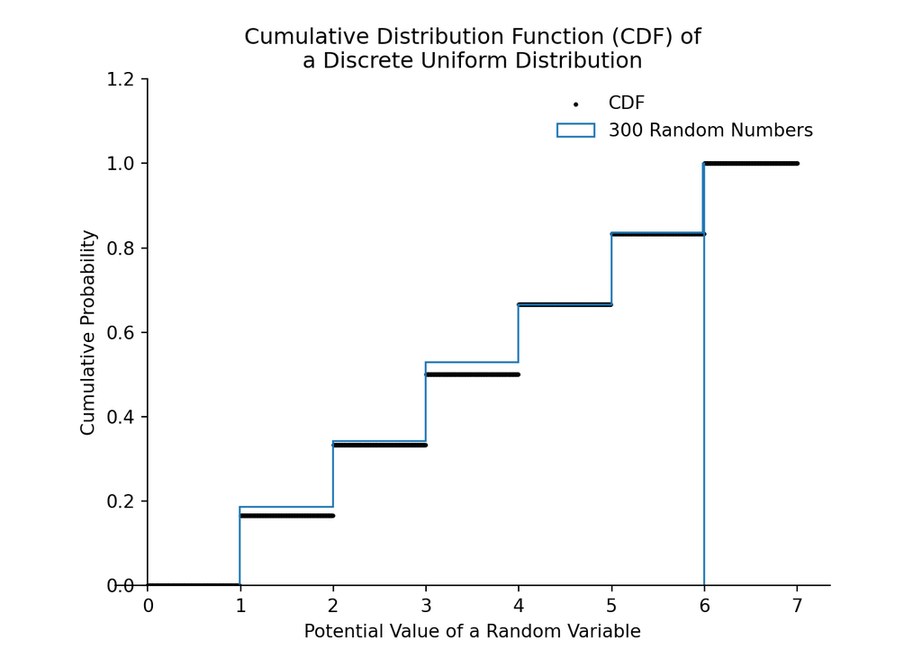

```python
# Create plot
ax = plt.axes()
title = """Cumulative Distribution Function (CDF) of
a Discrete Uniform Distribution"""
ax.set_title(title)
ax.set_ylabel('Cumulative Probability')
ax.set_xlabel('Potential Value of a Random Variable')
# Plot the CDF
ax.scatter(x, cdf, c='k', s=2, label='CDF')
# Plot the cumulative sum of the random numbers
label = '300 Random Numbers'
ax.hist(
    random_numbers, bins=300, density=True, cumulative=True,
    histtype='step', label=label, align='left'
)
# Move the left axis
ax.spines['left'].set_position(('data', 0))
# Remove the upper and right axes
ax.spines['right'].set_color('none')
ax.spines['top'].set_color('none')
# Adjust axes
plt.ylim([0, 1.2])
# Finish
ax.legend(frameon=False)
plt.show()
```

See also the [Wikipedia page](https://en.wikipedia.org/wiki/Discrete_uniform_distribution), [SciPy documentation](https://docs.scipy.org/doc/scipy/reference/generated/scipy.stats.randint.html) and [NumPy documentation](https://numpy.org/doc/stable/reference/random/generated/numpy.random.randint.html) relevant to the discrete uniform distribution.

⇦ Back